# 🐍 Practice n°3: regression (students version)

The objective of this session is to understand the regression problems and the analytical approach to solve them. This notebook discusses theoretical notions and contains practical parts.

Here are the main steps of the notebook :

1. What is regression ?
2. Focus on linear regression
3. Preparation
4. Implementation of a linear regression
5. Model improvement

## 1. What is regression ?

Regression in machine learning consists of mathematical methods that allow to predict a continuous outcome (y) based on the value of one or more predictor variables (x)

### 1D Example

x = Number of aircrafts in an airspace sector

y = Subjective rating of air traffic controller workload

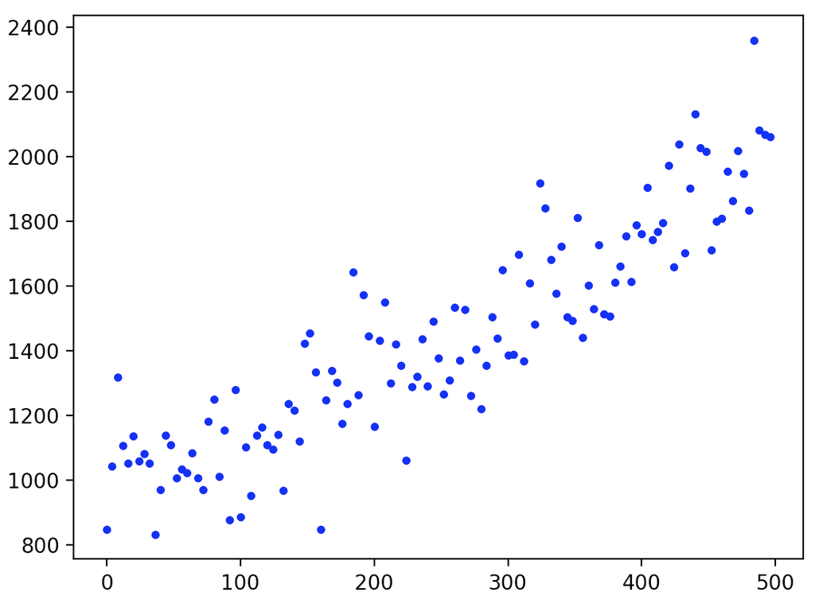

To predict the air traffic controller workload, we need to find the best function y=f(x). For that, we will define an error and find the function which minimizes this error.

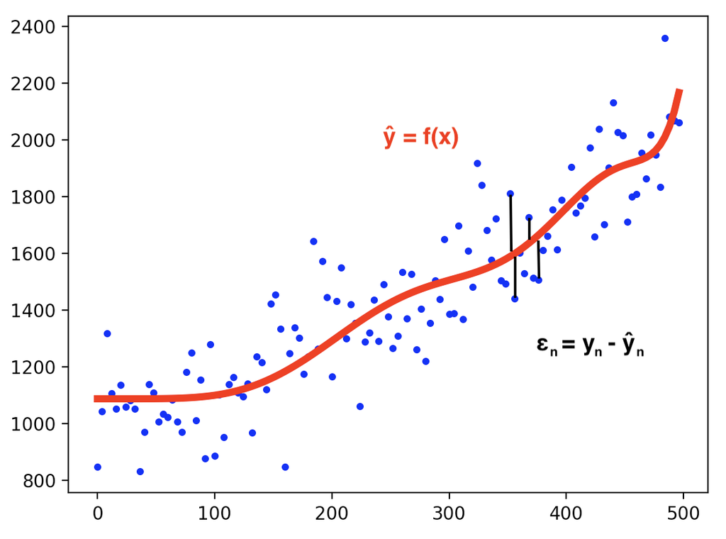

### Generalisation

In reality, we often deal with multiple explicative variables and the dimensionality of the input data is greater than 1.

$$x = (x_1,...,x_n)$$ $$\hat{y} = f(x_1,...,x_n)$$

If we come back to our traffic control example, the air traffic controller workload can be a function of both the number of aircraft and the weather.

## 2. Focus on linear regression

The linear regression is a regression using a linear function ŷ = ax + b

### 1D Example

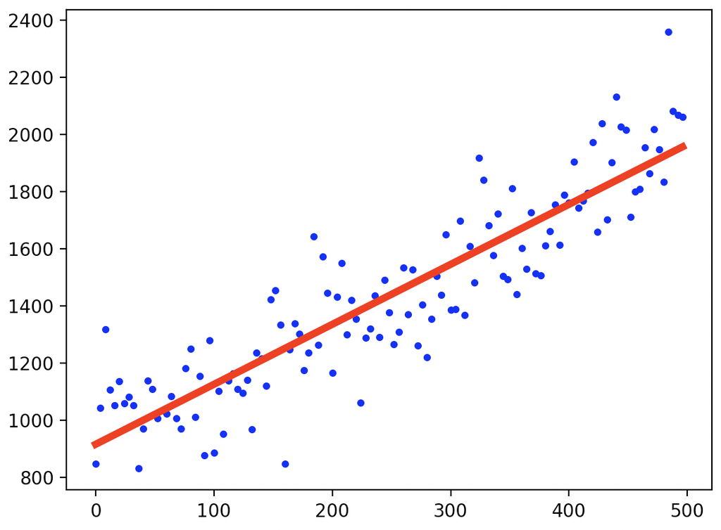

### Generalisation

In reality, we often deal with multiple explicative variables and the dimensionality of the input data is greater than 1. The linear function will look like :

$$\hat{y} = \beta_0 + \beta_1x_1 + \beta_2x_2 + ... + \beta_nx_n$$

Now let's practice with the ratebeer dataset !

# 3. Preparation

### Install & import modules

```python
import pandas as pd
from wordcloud import STOPWORDS
import numpy as np
from sklearn import (
    linear_model,
    preprocessing,
    pipeline,
    model_selection,
    metrics,
    compose,
)
import seaborn as sns
import matplotlib.pyplot as plt
from tqdm import tqdm
import matplotlib as mpl

mpl.rcParams['agg.path.chunksize'] = 10000
pd.set_option("display.precision", 2)
sns.set_style("whitegrid")
sns.set_context(rc={"patch.linewidth": 0.15})
```

### Read remote dataset

The data is in this git repository: ML-boot-camp/ratebeer.git.

The data is located in the the `ratebeer/data/` folder.

```python
file_url = "https://github.com/ML-boot-camp/ratebeer/raw/master/data/ratebeer_sample_enriched.parquet"
```

## Implementation of a linear regression

In this first section, you will train a linear regression model to predict the overall rating of a review based on its other ratings. For that, you will :

- Load & describe the data
- Split the data between train and test set
- Train and evaluate the linear regression model

## Load data & describe

```python
df_master = pd.read_parquet(file_url)
```

```python
df_master.head()
```

```python
df_master.shape
```